# Reproducible Research: Peer Assessment 1

## Loading and preprocessing the data

Show any code that is needed to: 1. Load the data (i.e. `read.csv()`) 2. Process/transform the data (if necessary) into a format suitable for your analysis

```r
# Download and unzip dataset if activity.csv doesn't exist
if (!file.exists("activity.csv")) {
    file_url <- "https://d396qusza40orc.cloudfront.net/repdata%2Fdata%2Factivity.zip"
    download.file(file_url, destfile = "activity.zip", mode = "wb")
    unzip("activity.zip")
}

# Load data
activity <- read.csv("activity.csv", colClasses = c("integer", "Date", "integer"))

# Check data structure
str(activity)
```

```
## 'data.frame':    17568 obs. of  3 variables:
##  $ steps   : int  NA NA NA NA NA NA NA NA NA NA ...
##  $ date    : Date, format: "2012-10-01" "2012-10-01" ...
##  $ interval: int  0 5 10 15 20 25 30 35 40 45 ...
```

```r
head(activity)
```

```
##   steps       date interval
## 1    NA 2012-10-01        0
## 2    NA 2012-10-01        5
## 3    NA 2012-10-01       10
## 4    NA 2012-10-01       15
## 5    NA 2012-10-01       20
## 6    NA 2012-10-01       25
```

## What is mean total number of steps taken per day?

For this part of the assignment, we can ignore the missing values in the dataset. 1. Calculate the total number of steps taken per day 2. Make a histogram of the total number of steps taken each day 3. Calculate and report the mean and median of the total number of steps taken per day

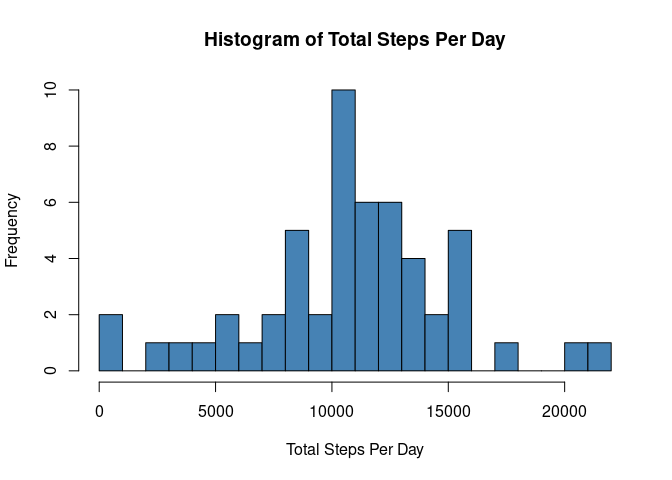

```r
# Calculate total steps per day
steps_per_day <- aggregate(steps ~ date, data = activity, sum, na.rm = TRUE)

# Histogram of total steps per day
hist(steps_per_day$steps,
     main = "Histogram of Total Steps Per Day",
     xlab = "Total Steps Per Day",
     col = "steelblue",
     breaks = 20)
```

```r
# Calculate mean and median
mean_steps <- mean(steps_per_day$steps)
median_steps <- median(steps_per_day$steps)

print(paste("Mean total steps per day:", round(mean_steps, 2)))
```

```
## [1] "Mean total steps per day: 10766.19"
```

```r
print(paste("Median total steps per day:", median_steps))
```

```
## [1] "Median total steps per day: 10765"
```

## What is the average daily activity pattern?

1. Make a time series plot (i.e. `type = "l"`) of the 5-minute interval (x-axis) and the average number of steps taken, averaged across all days (y-axis)
2. Which 5-minute interval, on average across all the days in the dataset, contains the maximum number of steps?

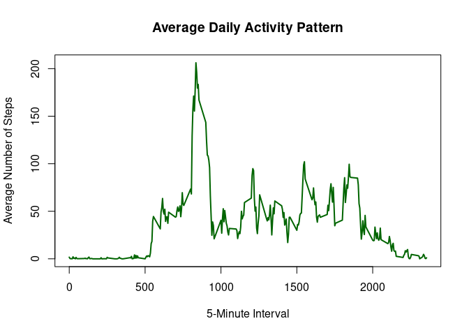

```r
# Calculate average steps per 5-minute interval across all days
avg_steps_interval <- aggregate(steps ~ interval, data = activity, mean, na.rm = TRUE)

# Time series plot
plot(avg_steps_interval$interval, avg_steps_interval$steps, type = "l",
     main = "Average Daily Activity Pattern",
     xlab = "5-Minute Interval",
     ylab = "Average Number of Steps",
     col = "darkgreen", lwd = 2)
```

```r
# Find interval with the maximum average steps
max_interval <- avg_steps_interval[which.max(avg_steps_interval$steps), ]
print(paste("Interval containing max steps on average:", max_interval$interval))
```

```
## [1] "Interval containing max steps on average: 835"
```

```r
print(paste("Maximum average steps:", round(max_interval$steps, 2)))
```

```
## [1] "Maximum average steps: 206.17"
```

## Imputing missing values

Note that there are a number of days/intervals where there are missing values (`NA`). The presence of missing days may introduce bias into some calculations or summaries of the data. 1. Calculate and report the total number of missing values in the dataset (i.e. the total number of rows with `NA`s) 2. Devise a strategy for filling in all of the missing values in the dataset. 3. Create a new dataset that is equal to the original dataset but with the missing data filled in. 4. Make a histogram of the total number of steps taken each day and calculate and report the mean and median total number of steps taken per day.

```r
# Total missing values
total_missing <- sum(is.na(activity$steps))
print(paste("Total missing rows:", total_missing))
```

```
## [1] "Total missing rows: 2304"
```

```r
# Strategy: Fill NA values with the mean for that respective 5-minute interval
get_interval_mean <- function(interval) {
    avg_steps_interval[avg_steps_interval$interval == interval, "steps"]
}

# Create new dataset with imputed values
activity_imputed <- activity
for (i in 1:nrow(activity_imputed)) {
    if (is.na(activity_imputed$steps[i])) {
        activity_imputed$steps[i] <- get_interval_mean(activity_imputed$interval[i])
    }
}

# Verify no missing values remain
sum(is.na(activity_imputed$steps))
```

```
## [1] 0
```

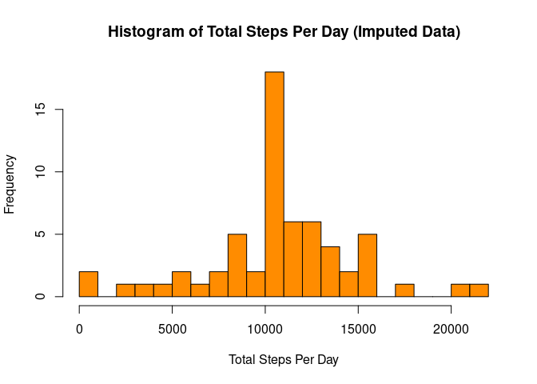

```r
# Aggregate total steps per day using imputed dataset
steps_per_day_imputed <- aggregate(steps ~ date, data = activity_imputed, sum)

# Histogram of total steps per day (imputed)
hist(steps_per_day_imputed$steps,
     main = "Histogram of Total Steps Per Day (Imputed Data)",
     xlab = "Total Steps Per Day",
     col = "darkorange",
     breaks = 20)
```

```r
# Calculate new mean and median
mean_steps_imp <- mean(steps_per_day_imputed$steps)
median_steps_imp <- median(steps_per_day_imputed$steps)

print(paste("Imputed Mean total steps per day:", round(mean_steps_imp, 2)))
```

```
## [1] "Imputed Mean total steps per day: 10766.19"
```

```r
print(paste("Imputed Median total steps per day:", median_steps_imp))
```

```
## [1] "Imputed Median total steps per day: 10766.1886792453"
```

## Are there differences in activity patterns between weekdays and weekends?

For this part the `weekdays()` function may be of some help here. Use the dataset with the filled-in missing values for this part. 1. Create a new factor variable in the dataset with two levels – “weekday” and “weekend” indicating whether a given date is a weekday or weekend day. 2. Make a panel plot containing a time series plot (i.e. `type = "l"`) of the 5-minute interval (x-axis) and the average number of steps taken, averaged across all weekday days or weekend days (y-axis).

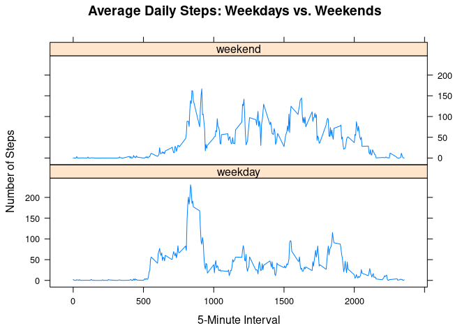

```r
# Create factor variable for weekday/weekend
activity_imputed$day_type <- as.factor(ifelse(weekdays(activity_imputed$date) %in% c("Saturday", "Sunday"), "weekend", "weekday"))

# Aggregate average steps by interval and day type
avg_steps_by_day_type <- aggregate(steps ~ interval + day_type, data = activity_imputed, mean)

# Panel plot using lattice
library(lattice)
xyplot(steps ~ interval | day_type, data = avg_steps_by_day_type, type = "l", layout = c(1, 2),
       main = "Average Daily Steps: Weekdays vs. Weekends",
       xlab = "5-Minute Interval",
       ylab = "Number of Steps")
```